# Practicum I CS5200

Wenhao Li

Summer Full 2023

## Connect to Database

Establish link to database at freemysqlhosting.net

```r
library(RMySQL)
db_name_fh <- "sql3654492"
db_user_fh <- "sql3654492"
db_host_fh <- "sql3.freemysqlhosting.net"
db_pwd_fh <- "LfRIZIav7w"
db_port_fh <- 3306

mydb.fh <-  dbConnect(RMySQL::MySQL(), user = db_user_fh, password = db_pwd_fh,
                      dbname = db_name_fh, host = db_host_fh, port = db_port_fh)

dbcon <- mydb.fh
```

## Create Database

Table for airport

```sql
CREATE TABLE IF NOT EXISTS airport(
  aid INTEGER AUTO_INCREMENT PRIMARY KEY,
  airportName VARCHAR(50) DEFAULT 'unknown',
  airportState VARCHAR(50) DEFAULT 'unknown',
  airportCode VARCHAR(50) DEFAULT 'unknown'
)
```

Table for each flights

```sql
CREATE TABLE IF NOT EXISTS flights(
  fid INT PRIMARY KEY,
  flight_date DATE DEFAULT NULL,
  origin INT DEFAULT 1,
  airline VARCHAR(50) DEFAULT "unknown",
  aircraft VARCHAR(50) DEFAULT "unknown" ,
  altitude INT UNSIGNED DEFAULT 0,
  heavy BOOLEAN DEFAULT FALSE,
  CONSTRAINT flights_fk_a FOREIGN KEY(origin) REFERENCES airport(aid)
)
```

Look up table: conditions

```sql
CREATE TABLE IF NOT EXISTS conditions(
  cid INT AUTO_INCREMENT PRIMARY KEY,
  sky_condition VARCHAR(50) DEFAULT "unknown",
  explanation VARCHAR(50) DEFAULT ""
)
```

Create table: strike

```sql
CREATE TABLE IF NOT EXISTS strike(
  sid INT AUTO_INCREMENT PRIMARY KEY,
  fid INT NOT NULL DEFAULT 1,
  numbirds INT DEFAULT 0,
  impact VARCHAR(50) DEFAULT "unknown",
  damage BOOLEAN DEFAULT FALSE,
  altitude INT UNSIGNED DEFAULT 0,
  conditions INT DEFAULT 1,
  CONSTRAINT positive_altitude CHECK(altitude >= 0),
  CONSTRAINT strike_fk_f FOREIGN KEY(fid) REFERENCES flights(fid),
  CONSTRAINT strike_fk_c FOREIGN KEY(conditions) REFERENCES conditions(cid)
)
```

## Tests for table implantation

```r
INSERT INTO airport VALUES
  ()
```

Should fail because of foreign key constrain

```r
INSERT INTO flights (fid, flight_date, origin, airline, aircraft, altitude, heavy) VALUES
  (202152, "2000-11-23", 1, "US AIRWAYS*", "B-737-400", 1500, TRUE)
```

Tests for table implantation

```r
INSERT INTO airport (airportName, airportState, airportCode) VALUES
  ("LAGUARDIA NY", "New York", "1"),
  ("DALLAS/FORT WORTH INTL ARPT", "Texas", "2")
```

Tests for table implantation

```r
SELECT *
FROM airport
```

altitude should convert to default value

```r
INSERT INTO flights
SET fid = 202152,
    flight_date = "2000-11-23",
    airline = "US AIRWAYS*",
    aircraft = "B-737-400",
    altitude = -1500,
    heavy = TRUE,
    origin = (
    SELECT aid
    FROM airport
    WHERE airportName = "LAGUARDIA NY")
```

Tests for table implantation

```r
SELECT * FROM flights
```

Tests for table implantation

```r
INSERT INTO conditions (sky_condition, explanation) VALUES
  ("NO CLOUD", ""),
  ("Some Cloud", "")
```

Tests for table implantation

```r
SELECT * FROM conditions
```

Tests for table implantation

```r
INSERT INTO strike
SET numbirds = 859,
    impact = "ENGINE SHUT DOWN",
    damage = TRUE,
    altitude = -1500,
    fid = 202152,
    conditions = 1
```

Tests for table implantation

```r
SELECT * FROM strike
```

Tests for table implantation

```r
DELETE FROM airport
```

Tests for table implantation

```r
DELETE FROM flights
```

Tests for table implantation

```r
DELETE FROM conditions
```

Tests for table implantation

```r
DELETE FROM strike
```

## Populate Database

Adding Default Conditions for each table except strike

```sql
INSERT INTO airport (airportCode) VALUES
  ("DEFAULT")
```

Adding Default Conditions for each table except strike

```sql
INSERT INTO flights
SET fid = 0,
    origin = (SELECT aid
              FROM airport
              WHERE airportName = "unknown" AND airportCode = "DEFAULT")
```

Adding Default Conditions for each table except strike

```sql
INSERT INTO conditions VALUES
  ()
```

Installing and loading of libraries

```r
install.packages("dplyr")
```

```
Error in install.packages : Updating loaded packages
```

```r
library(dplyr)
```

Manipulate dataframe for populating table

```r
fileName <- "BirdStrikesData-V2.csv"

df <- read.csv(fileName)

df <- data.frame(lapply(df, function(x) {gsub("\\*", "", x)}))

#Add "" to each column which will be inserted into the database as TEXT
df$airport <- paste('"', df$airport, '"')
df$model <- paste('"', df$model, '"')
df$impact <- paste('"', df$impact, '"')
df$airline <- paste('"', df$airline, '"')
df$origin <- paste('"', df$origin, '"')
df$sky_conditions <- paste('"', df$sky_conditions, '"')

#Change all colume that is empty or "N/A" to DEFAULT ("unknown" for TEXT, FALSE for boolean, 0 for INT)
df <- data.frame(lapply(df, function(x) {gsub('"  "', "DEFAULT", x)}))
df <- data.frame(lapply(df, function(x) {gsub('" N/A "', "DEFAULT", x)}))

#Delete space in TEXT
df <- data.frame(lapply(df, function(x) {gsub('" ', '"', x)}))
df <- data.frame(lapply(df, function(x) {gsub(' "', '"', x)}))
```

Importing Data into table airport

```r
#Group by function delete repeating rows
airport_df <-  df[] %>% group_by(airport, origin) %>%
                    summarise(.groups = 'drop',
                              empty_column = "",)

#Run insert for each row in airport_df
for (i in 1:nrow(airport_df)){
  row <- airport_df[i,]
  sql <- paste0('INSERT INTO airport (airportName, airportState, airportCode) VALUES (',
                row[1], ', ', row[2], ', DEFAULT)')
  dbExecute(dbcon, sql)
}
```

Importing Data into conditions

```r
#Group by function delete repeating rows
conditions_df <- df[] %>% group_by(sky_conditions) %>%
                    summarise(.groups = 'drop',
                              empty_column = "",)

#Run insert for each row in conditions_df
for (i in 1:nrow(conditions_df)){
  row <- conditions_df[i,]
  sql <- paste0('INSERT INTO conditions (sky_condition, explanation) VALUES (',
                row[1], ', ', row[2], 'DEFAULT)')
  dbExecute(dbcon, sql)
}
```

Importing Data into table flights

```r
#Group by function delete repeating rows
flights_df <- df[] %>% group_by(rid, flight_date, airport, origin, airline, model, altitude_ft, heavy_flag) %>%
                    summarise(.groups = 'drop')

#Convert date column to acceptable format
flights_df$flight_date <- as.Date(flights_df$flight_date, "%m/%d/%Y")
flights_df$flight_date <- as.character(flights_df$flight_date)

#Convert boolean columns to acceptable format
flights_df["heavy_flag"][flights_df["heavy_flag"] != "Yes"] <- "FALSE"
flights_df["heavy_flag"][flights_df["heavy_flag"] == "Yes"] <- "TRUE"

#Convert Default to coresponse value for sql query in FK insertion
flights_df["airport"][flights_df["airport"] == "DEFAULT"] <- '"unknown"'
flights_df["origin"][flights_df["origin"] == "DEFAULT"] <- '"unknown"'
flights_df["altitude_ft"][flights_df["altitude_ft"] == ""] <- "0"
flights_df["flight_date"][is.na(flights_df["flight_date"])] <- "DEFAULT"

#Delete comma in column altitude
flights_df$altitude_ft <- gsub(",","",flights_df$altitude_ft)

#Run insert for each row in flights_df
for (i in 1:nrow(flights_df)){
  row <- flights_df[i,]
  sql <- paste0('INSERT INTO flights SET fid = ',
                row[1], ', flight_date = "', row[2],
                '", origin = (SELECT aid FROM airport WHERE airportName = ',
                row[3], 'AND airportState = ', row[4],'), airline = ', row[5],
                ', aircraft = ', row[6], ', altitude = ', row[7], ', heavy = ', row[8])
  dbExecute(dbcon, sql)
}
```

Importing Data into table strike

```r
#Group by function delete repeating rows
strike_df <- df[] %>% group_by(rid, wildlife_struck, impact, damage, altitude_ft, sky_conditions) %>%
                    summarise(.groups = 'drop')

#Convert boolean columns to acceptable format
strike_df["damage"][strike_df["damage"] != "No damage"] <- "TRUE"
strike_df["damage"][strike_df["damage"] == "No damage"] <- "FALSE"
strike_df["altitude_ft"][strike_df["altitude_ft"] == ""] <- "0"

#Delete comma in column altitude
strike_df <- data.frame(lapply(strike_df, function(x) {gsub("\\,", "", x)}))

#Run insert for each row in strike_df
for (i in 1:nrow(strike_df)){
  row <- strike_df[i,]
  sql <- paste0('INSERT INTO strike SET fid = (SELECT fid FROM flights WHERE flights.fid = ',
                row[1], '), conditions = (SELECT cid FROM conditions WHERE sky_condition = ', row[6],
                '), numbirds = ', row[2], ', impact = ', row[3], ', damage = ', row[4],
                ', altitude = ', row[5])
  dbExecute(dbcon, sql)
}
```

Check table airport

```sql
SELECT *
FROM airport
LIMIT 0,10
```

| aid | airportName | airportState | airportCode |
| --- | --- | --- | --- |
| 3848 | ABERDEEN REGIONAL AR | South Dakota | unknown |
| 3849 | ABILENE REGIONAL ARPT | Texas | unknown |
| 3850 | ABRAHAM LINCOLN CAPITAL ARPT | Illinois | unknown |
| 3851 | ADAMS COUNTY- LEGION FIELD | Wisconsin | unknown |
| 3852 | ADAMS FIELD ARPT | Arkansas | unknown |
| 3853 | ADDINGTON FIELD ARPT | Kentucky | unknown |
| 3854 | ADDISON | Texas | unknown |
| 3855 | ADIRONDAK REGIONAL ARPT | New York | unknown |
| 3856 | AIRBORNE AIRPARK | Ohio | unknown |
| 3857 | AKRON-CANTON MUNICIPAL | Ohio | unknown |

Check table conditions

```sql
SELECT *
FROM conditions
```

| cid | sky_condition | explanation |
| --- | --- | --- |
| 26 | unknown |  |
| 27 | No Cloud |  |
| 28 | Overcast |  |
| 29 | Some Cloud |  |

Check table flights

```sql
SELECT *
FROM flights
LIMIT 0, 10
```

| fid | flight_date | origin | airline | aircraft | altitude | heavy |
| --- | --- | --- | --- | --- | --- | --- |
| 0 | NA | 4989 | unknown | unknown | 0 | 0 |
| 1195 | 2002-11-13 | 3904 | MILITARY | B-52H | 2000 | 0 |
| 3019 | 2002-10-10 | 4111 | MILITARY | T-38A | 400 | 0 |
| 3500 | 2001-05-15 | 3904 | MILITARY | B-52H | 1000 | 0 |
| 3504 | 2001-05-23 | 3904 | MILITARY | B-52H | 1800 | 0 |
| 3597 | 2001-04-18 | 4767 | MILITARY | AT-38B | 200 | 0 |
| 4064 | 2000-04-06 | 3904 | MILITARY | B-52H | 1000 | 0 |
| 4074 | 2002-07-15 | 4112 | MILITARY | F-16D | 0 | 0 |
| 4076 | 2002-07-15 | 3904 | MILITARY | B-52H | 500 | 0 |
| 4090 | 2001-07-02 | 3990 | MILITARY | C-17A | 50 | 0 |

Check table strike

```sql
SELECT *
FROM strike
LIMIT 0, 10
```

| sid | fid | numbirds | impact | damage | altitude | conditions |
| --- | --- | --- | --- | --- | --- | --- |
| 26598 | 1195 | 9 | None | 0 | 2000 | 28 |
| 26599 | 200011 | 1 | None | 0 | 0 | 28 |
| 26600 | 200012 | 1 | None | 0 | 0 | 28 |
| 26601 | 200022 | 1 | None | 1 | 2000 | 27 |
| 26602 | 200023 | 1 | None | 0 | 7000 | 27 |
| 26603 | 200028 | 1 | None | 0 | 3000 | 27 |
| 26604 | 200029 | 1 | None | 0 | 30 | 27 |
| 26605 | 200031 | 9 | None | 0 | 500 | 27 |
| 26606 | 200036 | 1 | None | 0 | 1000 | 27 |
| 26607 | 200037 | 1 | None | 0 | 0 | 29 |

## DATA ANALYSIS

Find the top 10 states with the greatest number of bird strike incidents

```sql
SELECT airportState AS state, COUNT(*) AS incidentsNum
FROM strike s
  INNER JOIN flights f ON s.fid = f.fid
  INNER JOIN airport a ON f.origin = a.aid
GROUP BY a.airportState
HAVING a.airportState != "unknown"
ORDER BY incidentsNum DESC
LIMIT 10
```

| state | incidentsNum |
| --- | --- |
| California | 2520 |
| Texas | 2453 |
| Florida | 2055 |
| New York | 1319 |
| Illinois | 1008 |
| Pennsylvania | 986 |
| Missouri | 960 |
| Kentucky | 812 |
| Ohio | 778 |
| Hawaii | 729 |

Find the airlines that had an above average number bird strike incidents

```sql
SELECT airline, incidentsNum
FROM (SELECT f.airline, COUNT(*) AS incidentsNum
      FROM strike s
        INNER JOIN flights f ON s.fid = f.fid
      GROUP BY f.airline
      HAVING f.airline != "unknown") AS t
WHERE incidentsNum >
      (SELECT AVG(incidentsNum) AS Average
      FROM (SELECT f.airline, COUNT(*) AS incidentsNum
            FROM strike s
              INNER JOIN flights f ON s.fid = f.fid
            GROUP BY f.airline
            HAVING f.airline != "unknown") AS t)
```

| airline | incidentsNum |
| --- | --- |
| ABX AIR | 189 |
| AIR CANADA | 95 |
| AIR WISCONSIN AIRLINES | 229 |
| AIRTRAN AIRWAYS | 414 |
| ALASKA AIRLINES | 304 |
| ALLEGIANT AIR | 107 |
| ALOHA AIRLINES | 135 |
| AMERICA WEST AIRLINES | 157 |
| AMERICAN AIRLINES | 2058 |
| AMERICAN EAGLE AIRLINES | 932 |

[output cut: 32 more lines]

```r
sql = "SELECT EXTRACT(MONTH FROM f.flight_date) AS month, COUNT(*) AS incidentsNum
       FROM flights f
         INNER JOIN strike s ON s.fid = f.fid
       WHERE f.flight_date != '0000-00-00'
       GROUP BY month"

month_df <- dbGetQuery(dbcon, sql)

print(month_df)
```

| month | incidentsNum |
| --- | --- |
| 1 | 937 |
| 2 | 772 |
| 3 | 1233 |
| 4 | 1828 |
| 5 | 2318 |
| 6 | 2078 |
| 7 | 3278 |
| 8 | 3710 |
| 9 | 3417 |
| 10 | 3039 |

[output cut: 2 more lines]

plot bird strike distribution each month

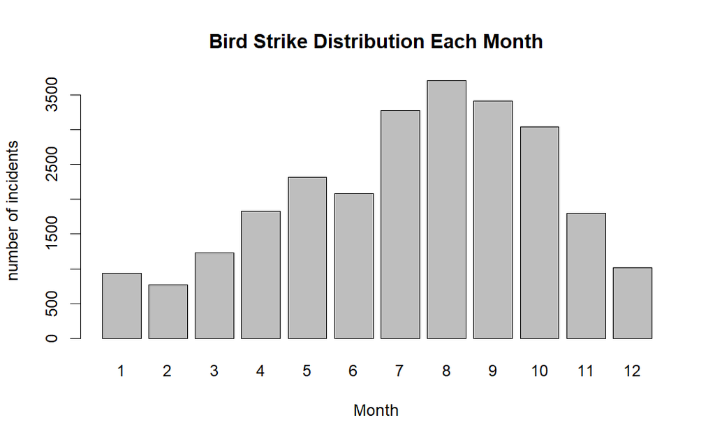

```r
barplot(month_df$incidentsNum, beside = FALSE, main = "Bird Strike Distribution Each Month",
        names.arg = month_df$month, xlab = "Month", ylab = "number of incidents")
```

## Store Procedure for add new incidents

adds a new strike to the database (store procedure)

```sql
CREATE PROCEDURE newEntry (IN new_sky_condition TEXT, IN new_airportName TEXT,
                           IN new_airportState TEXT, IN new_fid INT, IN new_flight_date DATE,
                           IN new_airline TEXT, IN new_aircraft TEXT, IN new_altitude INT,
                           IN new_heavy BOOLEAN, IN new_numbirds INT, IN new_impact TEXT,
                           IN new_damage BOOLEAN)
BEGIN
  IF (!EXISTS (SELECT * FROM conditions WHERE sky_condition = new_sky_condition)) THEN
    INSERT INTO conditions (sky_condition, explanation) VALUES (new_sky_condition, "");
  END IF;
  IF (!EXISTS (SELECT * FROM airport WHERE airportName = new_airportName
                                       AND airportState = new_airportState)) THEN
    INSERT INTO airport (airportName, airportState) VALUES (new_airportName, new_airportState);
  END IF;
  IF (!EXISTS (SELECT * FROM flights WHERE fid = new_fid)) THEN
    INSERT INTO flights SET fid = new_fid,
                            flight_date = new_flight_date,
                            origin = (SELECT aid FROM airport WHERE airportName = new_airportName
                                                                AND airportState = new_airportState),
                            airline = new_airline,
                            aircraft = new_aircraft,
                            altitude = new_altitude,
                            heavy = new_heavy;
  END IF;
  INSERT INTO strike SET fid = (SELECT fid FROM flights WHERE fid = new_fid),
                         numbirds = new_numbirds,
                         impact = new_impact,
                         damage = new_damage,
                         altitude = new_altitude,
                         conditions = (SELECT cid FROM conditions
                                       WHERE sky_condition = new_sky_condition);
END
```

Test Store Procedure

```sql
CALL newEntry("OK", "OK", "OK", 11, "1000-10-10", "OK", "OK", 0, FALSE, 1, "OK", FALSE)
```

Test Store Procedure

```sql
SELECT *
FROM strike
WHERE fid = 11
```

| sid | fid | numbirds | impact | damage | altitude | conditions |
| --- | --- | --- | --- | --- | --- | --- |
| 52156 | 11 | 1 | OK | 0 | 0 | 31 |

Test Store Procedure

```sql
DELETE FROM strike WHERE fid = 11
```

Test Store Procedure

```sql
DELETE FROM flights WHERE fid = 11
```

Test Store Procedure

```sql
DELETE FROM conditions WHERE sky_condition = "OK"
```

Test Store Procedure

```sql
DELETE FROM airport WHERE airportName = "OK"
```